# Final Project: Nutrition, Physical Activity, and Obesity Analysis

Your Name(s)

2024-12-08

## Data Description

The dataset used for this analysis is from the Behavioral Risk Factor Surveillance System and can be found at https://catalog.data.gov/dataset/nutrition-physical-activity-and-obesity-behavioral-risk-factor-surveillance-system/resource/0280bb9c-4de8-4b95-9642-93f727c4d305. The data provides health-related info on nutrition, physical activity, and obesity among adults in the United States. The data seems to be gathered annually (from 2011 - 2023) and contains variables related to location, health topics, data values, confidence intervals, and demographics

Key Variables:

`YearStart` and `YearEnd`: Indicate the time period of data collection. `LocationAbbr` and `LocationDesc`: Provide geographic information. `Class`, `Topic`, `Question`: Classify the health measures and behaviors. `Data_Value`: Represents the main health measurement. `Age`, `Education`, `Gender`, `Income`, `Race/Ethnicity`: Demographic categories for stratified analysis.

Another thing of note, many columns contain null values due to the varying nature of the `Question` variable. If we were to just remove all rows that have null column values, This would be a misstep.

## Primary Data Cleaning

```r
data_url <- "https://chronicdata.cdc.gov/api/views/hn4x-zwk7/rows.csv?accessType=DOWNLOAD"
data <- read_csv(data_url)
cleaned_data <- data %>%
  filter(!is.na(Data_Value))

View(cleaned_data)

cleaned_data <- cleaned_data %>%
  select(YearStart, LocationDesc, Class, Topic, Question, Data_Value, `Age(years)`, Education, Gender, Income, 'Race/Ethnicity')

summary(cleaned_data)
```

```
##    YearStart    LocationDesc          Class              Topic
##  Min.   :2011   Length:93505       Length:93505       Length:93505
##  1st Qu.:2014   Class :character   Class :character   Class :character
##  Median :2017   Mode  :character   Mode  :character   Mode  :character
##  Mean   :2017
##  3rd Qu.:2020
##  Max.   :2023
##    Question           Data_Value     Age(years)         Education
##  Length:93505       Min.   : 0.90   Length:93505       Length:93505
##  Class :character   1st Qu.:24.90   Class :character   Class :character
##  Mode  :character   Median :31.70   Mode  :character   Mode  :character
##                     Mean   :31.85
##                     3rd Qu.:37.50
##                     Max.   :85.30
##     Gender             Income          Race/Ethnicity
##  Length:93505       Length:93505       Length:93505
##  Class :character   Class :character   Class :character
##  Mode  :character   Mode  :character   Mode  :character
##
##
##
```

## Marginal Summaries

```r
summary(cleaned_data$Data_Value)
```

```
##    Min. 1st Qu.  Median    Mean 3rd Qu.    Max.
##    0.90   24.90   31.70   31.85   37.50   85.30
```

```r
class_counts <- cleaned_data %>%
  count(Class) %>%
  arrange(desc(n))

print(class_counts)
```

```
## # A tibble: 3 × 2
##   Class                       n
##   <chr>                   <int>
## 1 Physical Activity       49962
## 2 Obesity / Weight Status 35388
## 3 Fruits and Vegetables    8155
```

We can see that the average data_value lands right around 32-ish percent of any given group, so we will be able to use this as a gauge of “good” if a data value is greater than 32, and “bad” if the data value is less than 32.

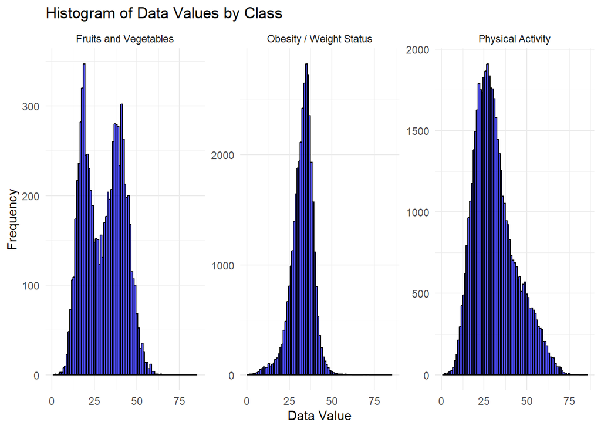

```r
ggplot(cleaned_data, aes(x = Data_Value)) +
  geom_histogram(binwidth = 1, fill = "blue", color = "black", alpha = 0.7) +
  labs(title = "Histogram of Data Values by Class", x = "Data Value", y = "Frequency") +
  facet_wrap(~ Class, scales = "free_y") +
  theme_minimal()
```

I thought it might be interesting to see the distribution of each class of data value, and the frequency that it occurred. This would give us some sort of idea what our data focused on, and how much a single statistic may vary.

## Questions to be Addressed

1. **How do nutrition, physical activity, and obesity metrics vary across different states?**
   - We will analyze how these health measures differ by location and explore geographic patterns.

```r
# Filter data for the specific question
obesity_data <- cleaned_data %>%
  filter(Question == "Percent of adults aged 18 years and older who have obesity") %>%
  select(LocationDesc, Data_Value)

# View the resulting dataframe
head(obesity_data)
```

```
## # A tibble: 6 × 2
##   LocationDesc Data_Value
##   <chr>             <dbl>
## 1 Alaska             23.3
## 2 Alaska             35.5
## 3 Alaska             29.5
## 4 Alaska             28
## 5 Alaska             26.7
## 6 Alaska             25.8
```

```r
# If you want the dataframe grouped by state:
state_obesity <- obesity_data %>%
  group_by(LocationDesc) %>%
  summarise(Average_Obesity_Percent = mean(Data_Value, na.rm = TRUE))

# View summarized data
head(state_obesity)
```

```
## # A tibble: 6 × 2
##   LocationDesc Average_Obesity_Percent
##   <chr>                          <dbl>
## 1 Alabama                         36.1
## 2 Alaska                          30.9
## 3 Arizona                         30.0
## 4 Arkansas                        36.3
## 5 California                      26.7
## 6 Colorado                        23.4
```

```r
highest_obesity <- state_obesity %>%
  arrange(desc(Average_Obesity_Percent))

# View the highest percentages
head(highest_obesity)
```

```
## # A tibble: 6 × 2
##   LocationDesc  Average_Obesity_Percent
##   <chr>                           <dbl>
## 1 West Virginia                    37.8
## 2 Mississippi                      37.6
## 3 Louisiana                        36.5
## 4 Arkansas                         36.3
## 5 Alabama                          36.1
## 6 Oklahoma                         35.2
```

```r
# Create a dataframe for the lowest percentages
lowest_obesity <- state_obesity %>%
  arrange(Average_Obesity_Percent)

# View the lowest percentages
head(lowest_obesity)
```

```
## # A tibble: 6 × 2
##   LocationDesc         Average_Obesity_Percent
##   <chr>                                  <dbl>
## 1 Colorado                                23.4
## 2 District of Columbia                    24.9
## 3 Hawaii                                  25.7
## 4 Massachusetts                           25.8
## 5 California                              26.7
## 6 New York                                27.0
```

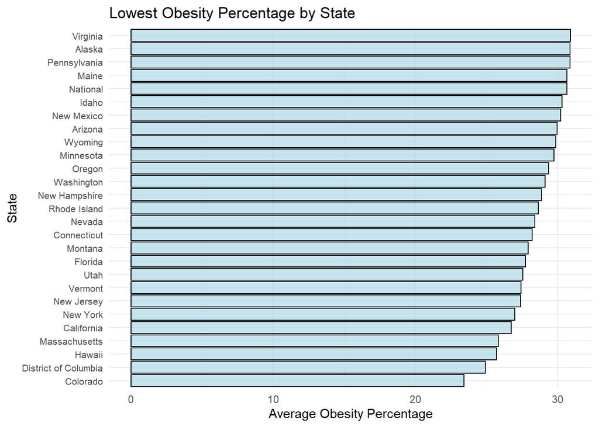

```r
# Ensure the states are ordered alphabetically
state_obesity <- state_obesity %>%
  arrange(LocationDesc)

# Split the data into two halves: lowest and highest
halfway_point <- nrow(state_obesity) / 2

# Lowest obesity data (first half)
lowest_half <- state_obesity %>%
  arrange(Average_Obesity_Percent) %>%
  head(halfway_point)

# Highest obesity data (second half)
highest_half <- state_obesity %>%
  arrange(desc(Average_Obesity_Percent)) %>%
  head(halfway_point)

# Plot for lowest obesity data
ggplot(lowest_half, aes(x = reorder(LocationDesc, Average_Obesity_Percent), y = Average_Obesity_Percent)) +
  geom_bar(stat = "identity", fill = "lightblue", color = "black", alpha = 0.7) +
  labs(
    title = "Lowest Obesity Percentage by State",
    x = "State",
    y = "Average Obesity Percentage"
  ) +
  theme_minimal() +
  coord_flip() +
  theme(axis.text.y = element_text(size = 8, hjust = 1))
```

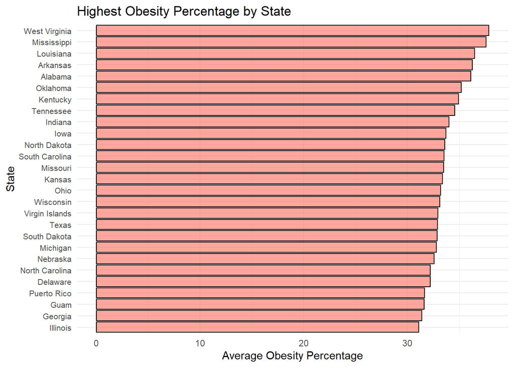

```r
# Plot for highest obesity data
ggplot(highest_half, aes(x = reorder(LocationDesc, Average_Obesity_Percent), y = Average_Obesity_Percent)) +
  geom_bar(stat = "identity", fill = "salmon", color = "black", alpha = 0.7) +
  labs(
    title = "Highest Obesity Percentage by State",
    x = "State",
    y = "Average Obesity Percentage"
  ) +
  theme_minimal() +
  coord_flip() +
  theme(axis.text.y = element_text(size = 8, hjust = 1))
```

2. **What demographic factors (age, gender, income, education, race/ethnicity) are most associated with variations in health metrics?**
   - We will investigate if there are significant differences in data values based on demographic stratifications.

```r
unique_qs <- unique(cleaned_data$Question)
head(unique_qs, 9)
```

```
## [1] "Percent of adults aged 18 years and older who have obesity"
## [2] "Percent of adults who achieve at least 150 minutes a week of moderate-intensity aerobic physical activity or 75 minutes a week of vigorous-intensity aerobic physical activity and engage in muscle-strengthening activities on 2 or more days a week"
## [3] "Percent of adults aged 18 years and older who have an overweight classification"
## [4] "Percent of adults who engage in muscle-strengthening activities on 2 or more days a week"
## [5] "Percent of adults who engage in no leisure-time physical activity"
## [6] "Percent of adults who achieve at least 150 minutes a week of moderate-intensity aerobic physical activity or 75 minutes a week of vigorous-intensity aerobic activity (or an equivalent combination)"
## [7] "Percent of adults who achieve at least 300 minutes a week of moderate-intensity aerobic physical activity or 150 minutes a week of vigorous-intensity aerobic activity (or an equivalent combination)"
## [8] "Percent of adults who report consuming fruit less than one time daily"
## [9] "Percent of adults who report consuming vegetables less than one time daily"
```

```r
# Split all the questions into their own df section (we'll use these later)
question_list <- split(cleaned_data, cleaned_data$Question)

head(question_list[[unique_qs[1]]])
```

```
## # A tibble: 6 × 11
##   YearStart LocationDesc Class  Topic Question Data_Value `Age(years)` Education
##       <dbl> <chr>        <chr>  <chr> <chr>         <dbl> <chr>        <chr>
## 1      2011 Alaska       Obesi… Obes… Percent…       23.3 <NA>         <NA>
## 2      2011 Alaska       Obesi… Obes… Percent…       35.5 <NA>         <NA>
## 3      2011 Alaska       Obesi… Obes… Percent…       29.5 35 - 44      <NA>
## 4      2011 Alaska       Obesi… Obes… Percent…       28   <NA>         <NA>
## 5      2011 Alaska       Obesi… Obes… Percent…       26.7 <NA>         <NA>
## 6      2011 Alaska       Obesi… Obes… Percent…       25.8 <NA>         Some col…
## # ℹ 3 more variables: Gender <chr>, Income <chr>, `Race/Ethnicity` <chr>
```

```r
# Assuming unique_qs is the vector of unique question names (e.g., obtained with unique(cleaned_data$Question))

# Loop over each unique question
for (i in 1:length(unique_qs)) {

  # Extract the data for the current question
  question_data <- question_list[[unique_qs[i]]]

  # Filter data based on condition, e.g., Gender == "Female"
  filtered_data <- question_data %>%
    filter(Gender == "Female")  # You can change the condition here

  # Plot the data
  ggplot(filtered_data, aes(x = reorder(LocationDesc, Data_Value), y = Data_Value)) +
    geom_bar(stat = "identity", fill = "lightblue", color = "black", alpha = 0.7) +
    labs(
      title = paste("Data for", unique_qs[i], "by Female"),
      x = "State",
      y = "Data Value"
    ) +
    theme_minimal() +
    coord_flip() +
    theme(axis.text.y = element_text(size = 8, hjust = 1))
}
```

3. **Has there been a significant change over time in key health metrics from YearStart to YearEnd?**
   - We will examine trends over the years to see if public health interventions have had an impact.
4. **What is the relationship between socioeconomic status (e.g., income, education) and health measures like obesity and physical activity?**
   - We will perform correlation and regression analyses to understand these relationships.